# AnSeqDa_exercise_1

Andrin Beeli

2023-09-19

## AnSeqDa excercise 1 (getting started)

### Plots:

[figure not shown]

```r
autoplot(goog) +
  ylab("Day") +
  xlab("closing stock price") +
  ggtitle("Daily stock prices of Google")
```

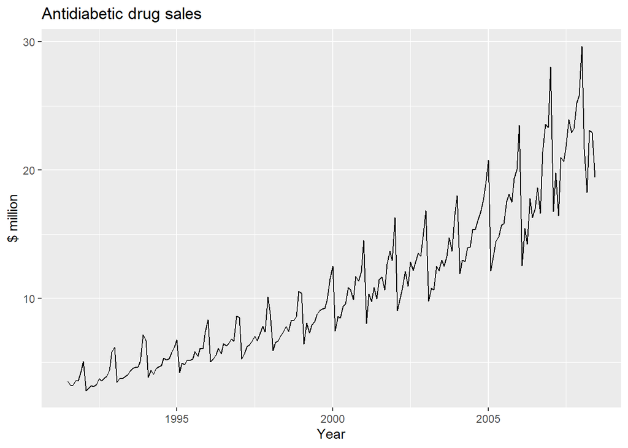

```r
# Seasonality and Trend
autoplot(a10) + ylab("$ million") + xlab("Year") +
  ggtitle("Antidiabetic drug sales")
```

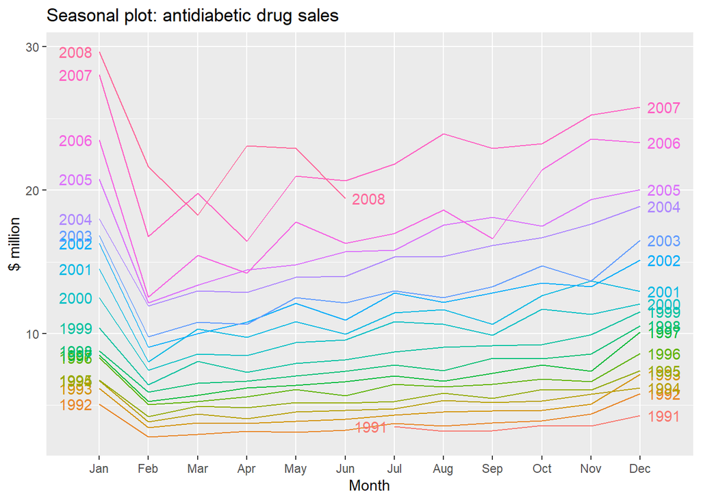

```r
# Plot seasonality per Month
ggseasonplot(a10, year.labels=TRUE, year.labels.left=TRUE) +
  ylab("$ million") +
  ggtitle("Seasonal plot: antidiabetic drug sales")
```

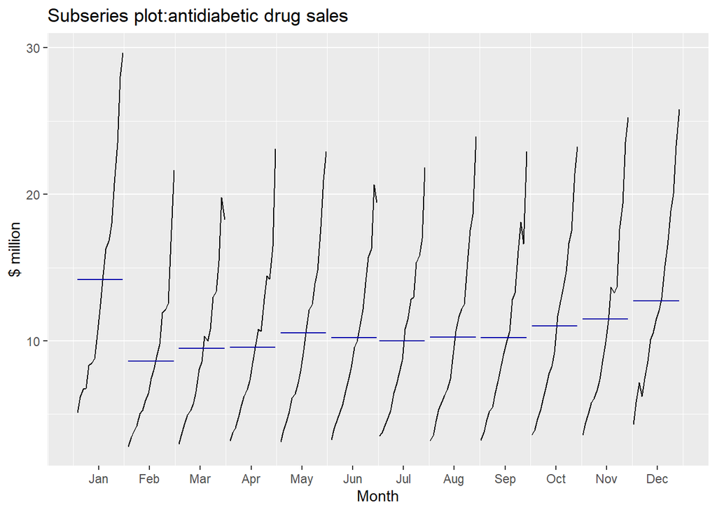

```r
ggsubseriesplot(a10) + ylab("$ million") +
  ggtitle("Subseries plot:antidiabetic drug sales")
```

### Results:

January shows the peak of sales and February the low. Reason of this peak is the applied account methods of the insurance. Therefore it is important to keep in mind that a model based on that data is not usful for other countries.

## Arrivals Data Seasonal Plots

The arrivals data set comprises quarterly international arrivals (in thousands) to Australia from Japan, New Zealand, UK and the US.

- Use autoplot() and ggseasonplot() to compare the dierences between the arrivals from these four countries.
- ggseasonplot() should be applied to each column separately
- Can you identify any unusual observations?

### Plots:

```r
?arrivals
```

```
## starting httpd help server ... done
```

```r
str(arrivals)
```

```
##  Time-Series [1:127, 1:4] from 1981 to 2012: 14.76 9.32 10.17 19.51 17.12 ...
##  - attr(*, "dimnames")=List of 2
##   ..$ : NULL
##   ..$ : chr [1:4] "Japan" "NZ" "UK" "US"
```

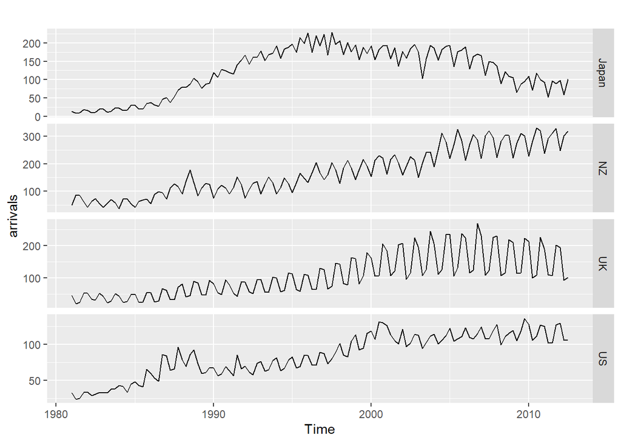

```r
autoplot(arrivals, facets = T)
```

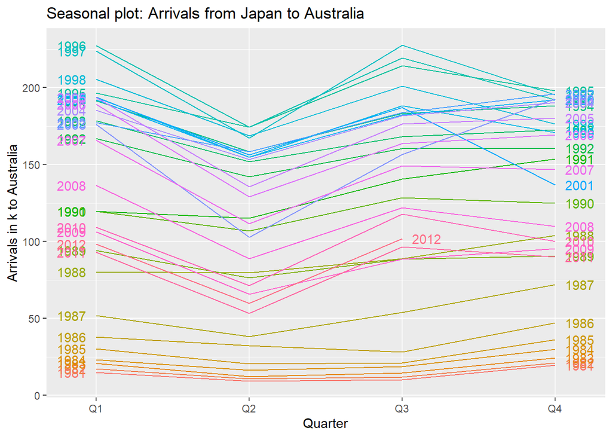

```r
ggseasonplot(arrivals[,1], year.labels=TRUE, year.labels.left=TRUE)  +
  ylab("Arrivals in k to Australia") +
  ggtitle("Seasonal plot: Arrivals from Japan to Australia")
```

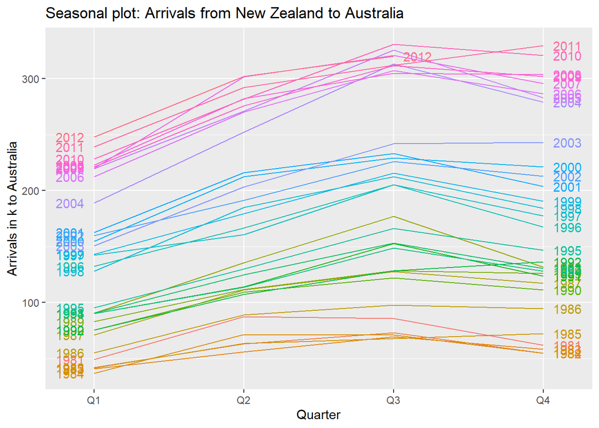

```r
ggseasonplot(arrivals[,2], year.labels=TRUE, year.labels.left=TRUE) +
  ylab("Arrivals in k to Australia") +
  ggtitle("Seasonal plot: Arrivals from New Zealand to Australia")
```

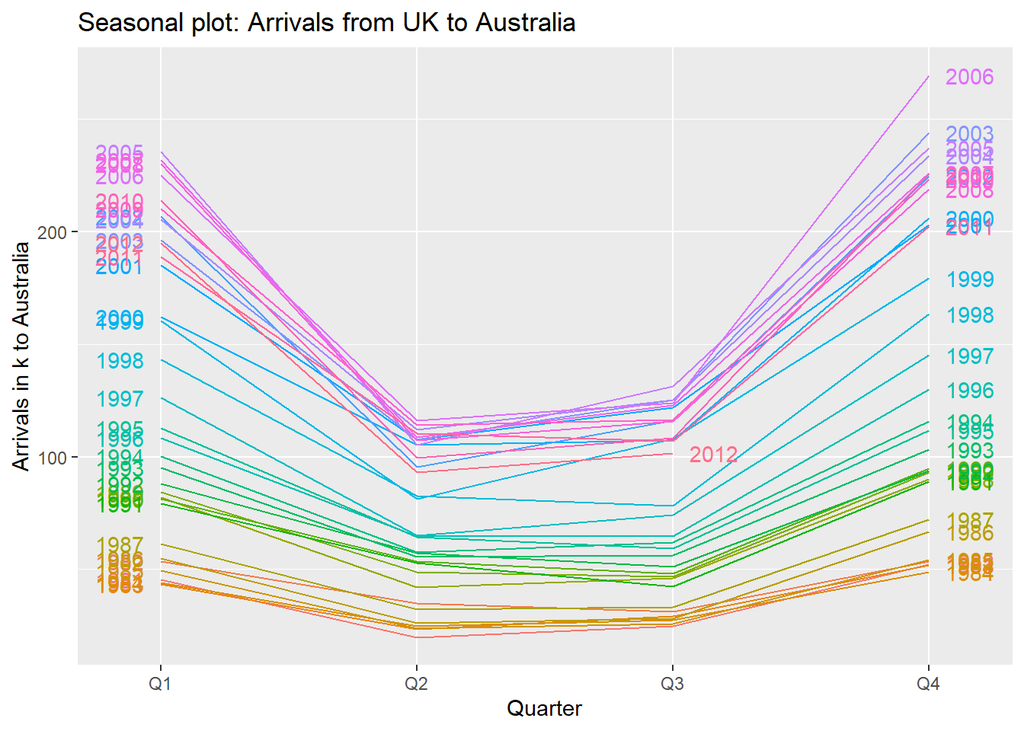

```r
ggseasonplot(arrivals[,3], year.labels=TRUE, year.labels.left=TRUE) +
  ylab("Arrivals in k to Australia") +
  ggtitle("Seasonal plot: Arrivals from UK to Australia")
```

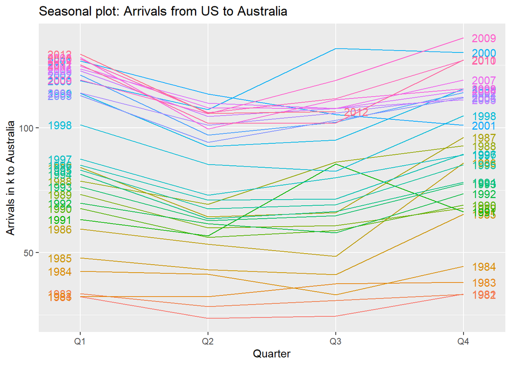

```r
ggseasonplot(arrivals[,4], year.labels=TRUE, year.labels.left=TRUE) +
  ylab("Arrivals in k to Australia") +
  ggtitle("Seasonal plot: Arrivals from US to Australia")
```

### Results:

Japan: some seasonality from 1995

NZ: upwards trend and seasonality

UK: strong seasoality

US: some seasonality from 1995

**Check of Japan and US with sliced data from 1995**

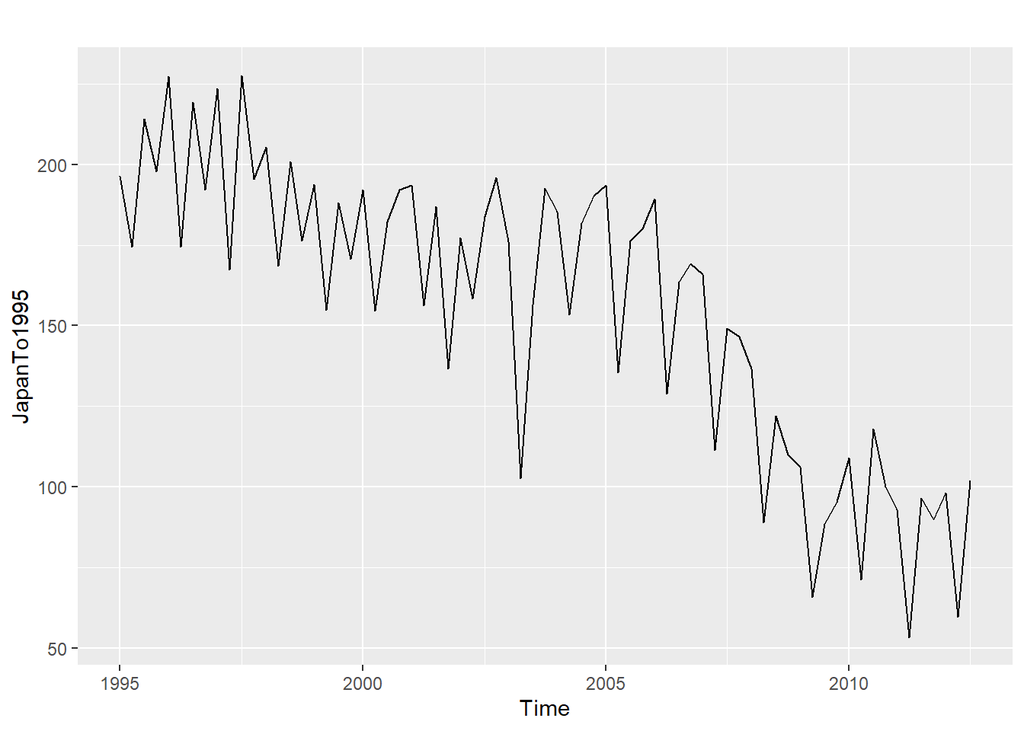

```r
JapanTo1995 <- window(arrivals[,1], start=c(1995,1))
autoplot(JapanTo1995)
```

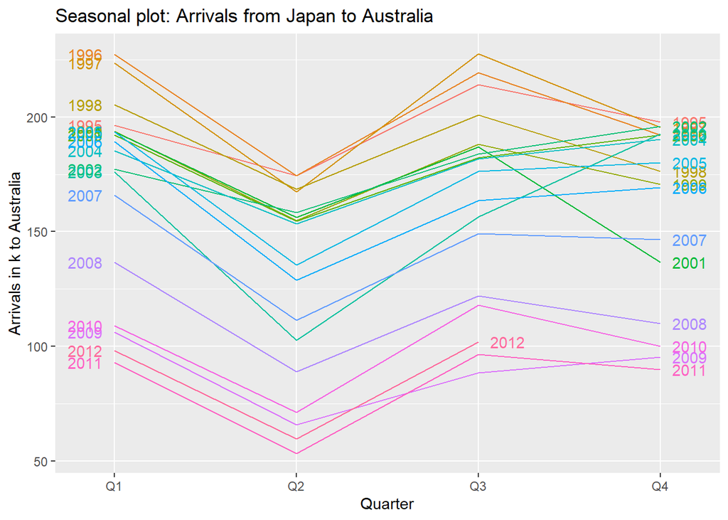

```r
ggseasonplot(JapanTo1995, year.labels=TRUE, year.labels.left=TRUE)  +
  ylab("Arrivals in k to Australia") +
  ggtitle("Seasonal plot: Arrivals from Japan to Australia")
```

US

[figure not shown]

```r
USto1995 <- window(arrivals[,4], start=c(1995,1))
autoplot(JapanTo1995)
```

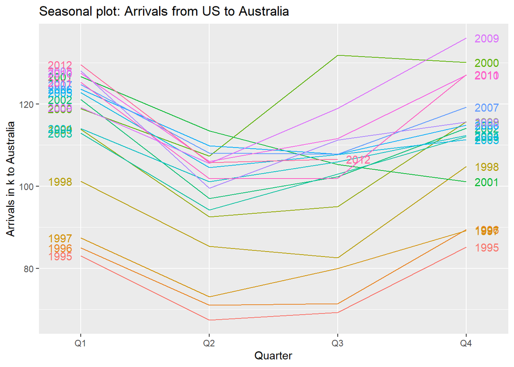

```r
ggseasonplot(USto1995, year.labels=TRUE, year.labels.left=TRUE)  +
  ylab("Arrivals in k to Australia") +
  ggtitle("Seasonal plot: Arrivals from US to Australia")
```